# Processing of Gendered and Gender-Neutral Professional and Personal Titles

Bran Papineau

June 2021

```r
library(ggplot2)
library(tidyverse)
library(lme4)
library(stringr)
library(languageR)
library(lmerTest)
library(reshape2)

source("helpers.R")
source("merge_results.R")
```

```
[1] "Not enough arguments supplied!"
```

```r
exp1 <- read.csv("gender_processing_data_final.csv") %>%
  filter(region == 'critical')
```

```r
summary(exp1)
```

```
    workerid     proliferate.condition  condition             form              lexeme
 Min.   :125.0   Length:4000           Length:4000        Length:4000        Length:4000
 1st Qu.:179.5   Class :character      Class :character   Class :character   Class :character
 Median :234.5   Mode  :character      Mode  :character   Mode  :character   Mode  :character
 Mean   :234.5
 3rd Qu.:289.2
 Max.   :341.0

     name              region          response_correct       rt            trial_id
 Length:4000        Length:4000        Min.   :0.0000   Min.   :    2.0   Length:4000
 Class :character   Class :character   1st Qu.:1.0000   1st Qu.:  362.8   Class :character
 Mode  :character   Mode  :character   Median :1.0000   Median :  504.0   Mode  :character
                                       Mean   :0.9523   Mean   :  671.6
                                       3rd Qu.:1.0000   3rd Qu.:  731.0
                                       Max.   :1.0000   Max.   :39051.0

    trial_no        word_idx subject_information.age subject_information.asses
 Min.   : 1.00   Min.   :3   Min.   :18.00           Length:4000
 1st Qu.: 5.75   1st Qu.:3   1st Qu.:23.00           Class :character
 Median :10.50   Median :3   Median :30.00           Mode  :character
 Mean   :10.50   Mean   :3   Mean   :32.69
 3rd Qu.:15.25   3rd Qu.:3   3rd Qu.:36.00
 Max.   :20.00   Max.   :3   Max.   :74.00
                             NA's   :40
 subject_information.comments subject_information.education subject_information.enjoyment
 Length:4000                  Min.   :-1.00                 Min.   :0.00
 Class :character             1st Qu.: 2.00                 1st Qu.:1.00
 Mode  :character             Median : 3.00                 Median :2.00
                              Mean   : 2.54                 Mean   :1.67
                              3rd Qu.: 3.00                 3rd Qu.:2.00
                              Max.   : 4.00                 Max.   :2.00

 subject_information.gender subject_information.gender_q1 subject_information.gender_q10
 Length:4000                Min.   :  0.00                Min.   :  0.00
 Class :character           1st Qu.: 83.00                1st Qu.:  0.00
 Mode  :character           Median : 97.00                Median : 12.50
                            Mean   : 89.84                Mean   : 21.07
                            3rd Qu.:100.00                3rd Qu.: 36.00
                            Max.   :100.00                Max.   :100.00

```

[output cut: 32 more lines]

```
 subject_information.party_alignment subject_information.price system.Browser      system.OS
 Min.   :1.000                       Min.   :0.000             Length:4000        Length:4000
 1st Qu.:3.000                       1st Qu.:1.000             Class :character   Class :character
 Median :4.000                       Median :1.000             Mode  :character   Mode  :character
 Mean   :3.722                       Mean   :0.965
 3rd Qu.:5.000                       3rd Qu.:1.000
 Max.   :5.000                       Max.   :1.000
 NA's   :40
 system.screenH   system.screenW time_in_minutes   error
 Min.   : 614.0   Min.   :1092   Min.   : 2.181   Mode:logical
 1st Qu.: 800.0   1st Qu.:1366   1st Qu.: 3.764   NA's:4000
 Median : 900.0   Median :1536   Median : 4.848
 Mean   : 929.3   Mean   :1603   Mean   : 5.382
 3rd Qu.:1080.0   3rd Qu.:1920   3rd Qu.: 6.122
 Max.   :1440.0   Max.   :2560   Max.   :30.623
```

```r
exp1_demographics <- exp1 %>%
  group_by(workerid) %>%
  summarise(age = unique(subject_information.age), gender = unique(subject_information.gender))
```

```r
table(exp1_demographics$gender)
```

```
       Female   Male  Other
     3    105     88      4
```

```r
summary(exp1_demographics$age)
```

```
   Min. 1st Qu.  Median    Mean 3rd Qu.    Max.    NA's
  18.00   23.00   30.00   32.69   36.00   74.00       2
```

```r
table(exp1_demographics$age)
```

```
18 19 20 21 22 23 24 25 26 27 28 29 30 31 32 33 34 35 36 37 38 39 40 41 44 45 46 47 49 51 52 53 56 57 60
 5  5 19  5  6 13  8  4  6 10  6  7  7  8  5 12  8 11  4  3  2  2  3  3  4  2  2  4  2  5  1  1  2  1  1
61 62 64 65 67 68 74
 1  1  1  3  2  2  1
```

```r
exclusion <- exp1 %>% group_by(workerid) %>%
  summarise(accuracy = mean(response_correct), browser = paste(unique(system.Browser))) %>%
  mutate(exclude = ifelse(accuracy < 0.85,'Yes','No')) %>%
  filter(exclude == 'Yes')

exp1 <- exp1[!(exp1$workerid %in% exclusion$workerid),] %>%
  filter(rt !='null')
```

```r
exp1 <- exp1 %>%
  group_by(trial_id) %>%
  mutate(id_mean = mean(log(rt))) %>%
  mutate(exclusion = (log(rt) < mean(log(rt)) - 2*sd(log(rt))|(log(rt) > mean(log(rt)) + 2*sd(log(rt))))) %>%
  ungroup() %>%
  filter(exclusion==FALSE)
```

## 0.1 Adding in Additional Important Trial Information

Now that we have only the rows we want, let’s add some new columns, which will contain important information for each data point. Here, we will be adding:

- Gender Ideology Subscores
- Trial Genders
- Trial Morphology Types
- Critical Item Length & Length-Controlled Residuals
- Trial Congruency
- Partipant Political Affiliation

Ideally, I would’ve added all of these but the first when I actually created the stimuli and logged responses, but I forgot to! Luckily, R allows us to do this post-hoc fairly straightforwardly… which is good, since these features will be critical in our data visualization and analysis.

### 0.1.1 Defining Gender Subscores

The question under investigation here is whether or not individuals’ conceptions of gender affect how they process gendered and gender-neutral forms of English personal and professional titles.  
In order to examine this, we need to quanify participants’ ideological views! Here we have adopted the 13-item Social Roles Questionnaire put forth in Baber & Tucker (2006). Questions 1-5 correlate to the *‘Gender Transcendent’* subscale, and questions 6-13 correspond to the *‘Gender Linked’* subscale. Each item is scored on a scale of 0-100. So, the first thing we want to do is make two lists of columns which correspond to these two subscales, since the questions are stored individually in the data:

```r
gender_transcendence_cols <- c('subject_information.gender_q1','subject_information.gender_q2','subject_information.gender_q3','subject_information.gender_q4','subject_information.gender_q5')

gender_linked_cols <- c('subject_information.gender_q6','subject_information.gender_q7','subject_information.gender_q8','subject_information.gender_q9','subject_information.gender_q10','subject_information.gender_q11','subject_information.gender_q12','subject_information.gender_q13')
```

Now we can use the mutate() method on **exp1** to add two new columns, one for each subscale. We tell R to take the means of the specified columns in [column_names] of **exp1** for each individual row: rowMeans(exp1[column_names]). We also have to subtract this mean from 100 in the case of the *‘Gender Transcendent’* subscale, since it is inversely scored. Finally, we can create an average total score regardless of subscores, simply by meaning the two subscores we already have.

```r
exp1 <- exp1 %>%
  mutate(gender_trans = 100 - (rowMeans(exp1[gender_transcendence_cols]))) %>%
  mutate(gender_link = rowMeans(exp1[gender_linked_cols]))

gender_all = c('gender_trans','gender_link')

exp1 <- exp1 %>%
  mutate(gender_total = rowMeans(exp1[gender_all]))
```

### 0.1.2 Adding Gender

We also want to add whether the trial included a female or male referent (but also, like, destroy the binary!). In order to do this, we’ll just add a **trial_gender** column that says *‘female’* if the condition was either *‘neutral_female’* or *‘congruent_female’*. Otherwise, we want the **trial_gender** to say *‘male’*.

```r
exp1 <- exp1 %>%
  mutate(trial_gender = ifelse(condition=='neutral_female' | condition == 'congruent_female','female','male'))

exp1 %>%
  select(workerid,rt,condition,trial_id,trial_gender)
```

| workerid | rt | condition | trial_id | trial_gender |
| --- | --- | --- | --- | --- |
| 201 | 392 | congruent_female | hero_congruent_female | female |
| 201 | 344 | congruent_female | businessperson_congruent_female | female |
| 201 | 368 | neutral_female | heir_neutral_female | female |
| 201 | 480 | congruent_female | anchor_congruent_female | female |
| 201 | 400 | congruent_male | salesperson_congruent_male | male |
| 201 | 265 | congruent_male | crewmember_congruent_male | male |
| 201 | 344 | congruent_female | stunt double_congruent_female | female |
| 201 | 504 | neutral_male | actor_neutral_male | male |
| 201 | 304 | neutral_male | meteorologist_neutral_male | male |
| 201 | 384 | neutral_female | police officer_neutral_female | female |

[output cut: 990 more lines]

### 0.1.3 Adding Morphology Type

Now we want to add whether or not the lexeme’s neutral form is developed by compounding (as in *‘congress-person’*) or by the adoption of the male form (as in *‘actor’* being used more for both men and women). In this study, we only have six lexemes of the latter type, so we’ll just tell R to assign those a **morph_type** value of *‘adoption’* (for ‘male adoption’), and all else will be assigned a value of *‘compound’*.

```r
exp1 <- exp1%>%
  mutate(morph_type = ifelse(lexeme!= 'actor' & lexeme!= 'host' & lexeme !='hunter' & lexeme!= 'villain' & lexeme!= 'heir' & lexeme!= 'hero','compound','adoption'))

exp1 %>%
  select(rt,lexeme,morph_type)
```

| rt | lexeme | morph_type |
| --- | --- | --- |
| 392 | hero | adoption |
| 344 | businessperson | compound |
| 368 | heir | adoption |
| 480 | anchor | compound |
| 400 | salesperson | compound |
| 265 | crewmember | compound |
| 344 | stunt double | compound |
| 504 | actor | adoption |
| 304 | meteorologist | compound |
| 384 | police officer | compound |

[output cut: 990 more lines]

### 0.1.4 Adding Form Length & Length-Controlled Residuals

Another important factor we want to explore is the length of the critical item! In order to add this, we simply create a new column **form_length** and tell R to input as that column’s value the length of the string that appears in that row’s **form** column, which corresponds to the orthograpic form of the critical item in that trial. *Note that this will include spaces in the count!*

```r
exp1 <- exp1 %>%
  mutate(form_length = str_length(form))

simple_model <- lm(log(rt)~form_length, data = exp1)

exp1 <- exp1 %>%
  mutate(resid_rt = resid(simple_model))
```

```r
summary(simple_model)
```

```
Call:
lm(formula = log(rt) ~ form_length, data = exp1)

Residuals:
     Min       1Q   Median       3Q      Max
-1.45139 -0.29801 -0.01522  0.32842  1.82764

Coefficients:
            Estimate Std. Error t value Pr(>|t|)
(Intercept) 5.990835   0.024897 240.624   <2e-16 ***
form_length 0.025137   0.002542   9.889   <2e-16 ***
---
Signif. codes:  0 ‘***’ 0.001 ‘**’ 0.01 ‘*’ 0.05 ‘.’ 0.1 ‘ ’ 1

Residual standard error: 0.4971 on 3564 degrees of freedom
Multiple R-squared:  0.02671,   Adjusted R-squared:  0.02643
F-statistic: 97.79 on 1 and 3564 DF,  p-value: < 2.2e-16
```

Now that we have these, we can run a simple linear regression which will show us the effect of orthographic length on reading time. Then we add a new column in the data which is the residual reading time, or the reading time in log space AFTER we control for the effects of orthographic length.

### 0.1.5 Adding Congruency Column

We also want to make sure we have a column which records whether or not the trial was gender-congruent (as in *‘Shelby is a congresswoman’*) or gender neutral (as in *‘Shelby is a congressperson’*). We add a **trial_congruency** column, which is valued as *‘congruent’* if that row’s condition is one of the two congruent conditions. Otherwise, it gets valued as *‘neutral’*.

```r
exp1 <- exp1 %>%
  mutate(trial_congruency = ifelse(condition=='congruent_male' | condition == 'congruent_female','congruent','neutral'))
```

### 0.1.6 Adding Large Political Macrocategories

Finally, we can classify participants by their particular political alignment; we can construe this broadly as “Republicans” vs. “Democrats”, with those who declined to state a preference, or placed themselves in the middle, as “Non-Partisan”.

```r
exp1 <- exp1 %>%
  mutate(poli_party = ifelse(subject_information.party_alignment == 1 | subject_information.party_alignment == 2,'Republican',ifelse(subject_information.party_alignment == 4 | subject_information.party_alignment == 5,'Democrat','Non-Partisan')))
```

# 1 Data Visualisation

```r
theme_set(theme_minimal())

inauguration_2021 = c("#5445b1", "#749dae", "#f3c483", "#5c1a33", "#cd3341","#f7dc6a")
```

```r
agg_speaker_mean_con <- exp1 %>%
  group_by(condition,workerid) %>%
  summarize(MeanRT=mean(resid_rt))
```

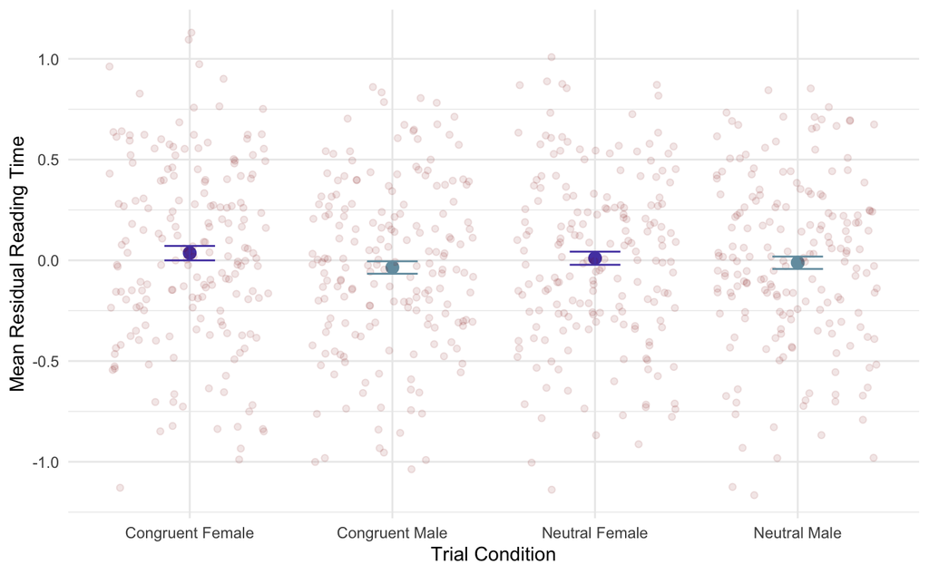

```r
exp1 %>%
  group_by(condition,trial_gender) %>%
  summarize(MeanRT = mean(resid_rt), CI.Low = ci.low(resid_rt), CI.High = ci.high(resid_rt)) %>%
  mutate(YMin = MeanRT - CI.Low, YMax = MeanRT + CI.High) %>%
  ggplot(aes(x=condition,y=MeanRT,color=trial_gender)) +
  geom_point(size=3) +
  geom_jitter(data = agg_speaker_mean_con, aes(y=MeanRT),alpha=.1,color='darkred') +
  geom_errorbar(aes(ymin=YMin,ymax=YMax), width=.25) +
  scale_color_manual(values = inauguration_2021,labels=c("female"="Female","male"="Male")) +
  labs(color= "Trial Gender", x="Trial Condition", y="Mean Residual Reading Time") +
  scale_x_discrete(labels=c("neutral_male" = "Neutral Male", "neutral_female"="Neutral Female", "congruent_female" = "Congruent Female", "congruent_male" = "Congruent Male")) +
  theme(legend.position = 'none')
```

```r
ggsave("experiment1main.png",height=3,width=5)
```

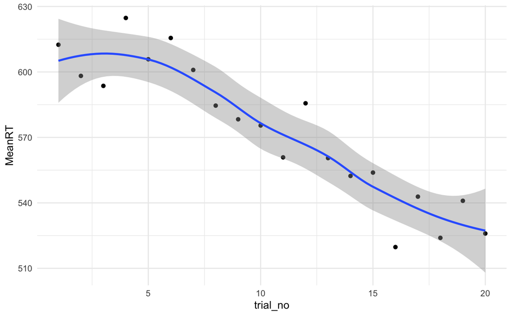

```r
exp1 %>%
  group_by(trial_no) %>%
  summarise(MeanRT = mean(rt)) %>%
  ggplot(aes(x=trial_no,y=MeanRT)) +
  geom_point() +
  geom_smooth() +
  theme_minimal()
```

```r
exp1 <- exp1 %>%
  mutate(ctrial_congruency = as.numeric(as.factor(trial_congruency))-mean(as.numeric(as.factor(trial_congruency)))) %>%
  mutate(ctrial_gender = as.numeric(as.factor(trial_gender))-mean(as.numeric(as.factor(trial_gender)))) %>%
  mutate(cgender_link = scale(gender_link)) %>%
  mutate(cgender_total = scale(gender_total)) %>%
  mutate(cmorph_type = as.numeric(as.factor(morph_type))-mean(as.numeric(as.factor(morph_type))))
```

```r
complex_model <- lmer(resid_rt~ctrial_congruency*ctrial_gender*cgender_total + (1|workerid) + (1|lexeme),data = exp1)
```

```r
summary(complex_model)
```

```
Linear mixed model fit by REML. t-tests use Satterthwaite's method ['lmerModLmerTest']
Formula: resid_rt ~ ctrial_congruency * ctrial_gender * cgender_total +
    (1 | workerid) + (1 | lexeme)
   Data: exp1

REML criterion at convergence: 2524.4

Scaled residuals:
    Min      1Q  Median      3Q     Max
-3.9028 -0.5973 -0.0515  0.5331  4.8658

Random effects:
 Groups   Name        Variance Std.Dev.
 workerid (Intercept) 0.157665 0.39707
 lexeme   (Intercept) 0.001128 0.03359
 Residual             0.097444 0.31216
Number of obs: 3566, groups:  workerid, 186; lexeme, 20

Fixed effects:
                                                Estimate Std. Error         df t value Pr(>|t|)
(Intercept)                                    2.861e-03  3.053e-02  1.905e+02   0.094   0.9254
ctrial_congruency                             -3.768e-03  1.048e-02  3.363e+03  -0.360   0.7192
ctrial_gender                                 -4.477e-02  1.048e-02  3.364e+03  -4.271    2e-05 ***
cgender_total                                 -5.129e-02  2.948e-02  1.828e+02  -1.740   0.0836 .
ctrial_congruency:ctrial_gender                4.567e-02  2.097e-02  3.365e+03   2.178   0.0295 *
ctrial_congruency:cgender_total               -3.134e-03  1.049e-02  3.367e+03  -0.299   0.7652
ctrial_gender:cgender_total                   -1.106e-02  1.049e-02  3.365e+03  -1.054   0.2918
ctrial_congruency:ctrial_gender:cgender_total  7.834e-03  2.098e-02  3.365e+03   0.373   0.7088
---
Signif. codes:  0 ‘***’ 0.001 ‘**’ 0.01 ‘*’ 0.05 ‘.’ 0.1 ‘ ’ 1

Correlation of Fixed Effects:
                 (Intr) ctrl_c ctrl_g cgndr_ ctrl_cngrncy:ct_ ctrl_cngrncy:cg_ ctrl_g:_
ctrl_cngrnc       0.000
ctrial_gndr      -0.001 -0.001
cgender_ttl      -0.002 -0.001 -0.001
ctrl_cngrncy:ct_  0.000  0.000  0.000  0.000
ctrl_cngrncy:cg_ -0.001 -0.001  0.003 -0.001 -0.004
ctrl_gndr:_       0.000  0.004  0.000 -0.001  0.000           -0.002
ctrl_cn:_:_       0.000 -0.004  0.000 -0.001  0.002            0.000           -0.001
```

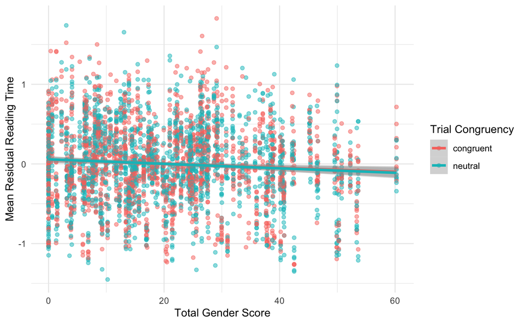

```r
ggplot(exp1, aes(x=gender_total, y=resid_rt, color=trial_congruency)) +
  geom_point(alpha=.5) +
  geom_smooth(method = 'lm', size=1.2) +
  theme_minimal() +
  labs(x="Total Gender Score", y="Mean Residual Reading Time",color="Trial Congruency")
```

```r
ggsave("experiment1ideo.png",height=3,width=5)
```

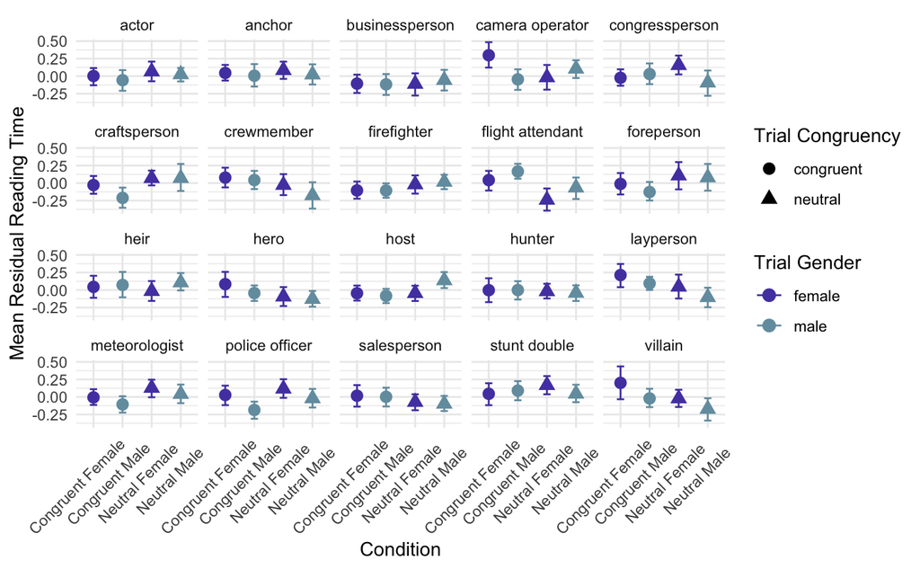

```r
exp1 %>%
  group_by(condition,trial_gender,trial_congruency,lexeme) %>%
  summarize(MeanRT = mean(resid_rt), CI.Low = ci.low(resid_rt), CI.High = ci.high(resid_rt)) %>%
  mutate(YMin = MeanRT - CI.Low, YMax = MeanRT + CI.High) %>%
  ggplot(aes(x=condition,y=MeanRT,color=trial_gender,shape=trial_congruency)) +
  geom_point(size=3) +
  geom_errorbar(aes(ymin=YMin,ymax=YMax), width=.25) +
  facet_wrap(~ lexeme) +
  theme(axis.text.x = element_text(angle = 45, vjust = .7, hjust=.7)) +
  scale_color_manual(values = inauguration_2021) +
  labs(x="Condition",y="Mean Residual Reading Time", color="Trial Gender", shape="Trial Congruency") +
  scale_x_discrete(labels=c("neutral_male" = "Neutral Male", "neutral_female"="Neutral Female", "congruent_female" = "Congruent Female", "congruent_male" = "Congruent Male"))
```

```r
ggsave("experiment1items.png",height=5,width=7)
```

```r
exp1 %>%
  filter(lexeme=='host')
```

| workerid | proliferate.condition | condition | form | lexeme | name | region | response_correct | rt | trial_id | trial_no | word_idx | subject_information.age | subject_information.asses | subject_information.comments | subject_information.education | subject_information.enjoyment | subject_information.gender | subject_information.gender_q1 | subject_information.gender_q10 | subject_information.gender_q11 | subject_information.gender_q12 | subject_information.gender_q13 | subject_information.gender_q2 | subject_information.gender_q3 | subject_information.gender_q4 | subject_information.gender_q5 | subject_information.gender_q6 | subject_information.gender_q7 | subject_information.gender_q8 | … |
| --- | --- | --- | --- | --- | --- | --- | --- | --- | --- | --- | --- | --- | --- | --- | --- | --- | --- | --- | --- | --- | --- | --- | --- | --- | --- | --- | --- | --- | --- | --- |
| 201 | all | neutral_male | host | host | Joshua | critical | 1 | 272 | host_neutral_male | 14 | 3 | 23 | Yes | n/a | 3 | 1 | Male | 100 | 0 | 61 | 0 | 0 | 100 | 100 | 100 | 100 | 94 | 67 | 17 | … |
| 162 | all | congruent_female | hostess | host | Megan | critical | 1 | 492 | host_congruent_female | 5 | 3 | 27 | Yes |  | 4 | 2 | Male | 100 | 50 | 57 | 7 | 8 | 83 | 100 | 100 | 89 | 72 | 49 | 55 | … |
| 222 | all | congruent_female | hostess | host | Madison | critical | 1 | 337 | host_congruent_female | 11 | 3 | 33 | Yes | I am probably being too over concerned about the instructions but one thing bothered me. Some questions went like this: "Michael is from New Mexico. He likes dancing" "Does Michael like camping?". And… | 2 | 1 | Female | 72 | 50 | 65 | 20 | 2 | 85 | 100 | 100 | 78 | 50 | 31 | 30 | … |
| 153 | all | neutral_male | host | host | Michael | critical | 1 | 172 | host_neutral_male | 15 | 3 | NA |  |  | 2 | 2 |  | 90 | 28 | 56 | 20 | 17 | 41 | 89 | 92 | 17 | 86 | 48 | 16 | … |
| 337 | all | congruent_female | hostess | host | Sarah | critical | 1 | 196 | host_congruent_female | 16 | 3 | 27 | Yes |  | 3 | 2 | Male | 91 | 62 | 50 | 13 | 16 | 100 | 100 | 81 | 74 | 81 | 66 | 57 | … |
| 302 | all | congruent_male | host | host | Joseph | critical | 1 | 507 | host_congruent_male | 3 | 3 | 57 | Yes |  | 2 | 1 | Male | 68 | 52 | 82 | 79 | 82 | 69 | 100 | 81 | 0 | 92 | 17 | 52 | … |
| 324 | all | neutral_female | host | host | Megan | critical | 1 | 403 | host_neutral_female | 2 | 3 | 20 | Yes |  | 2 | 2 | Female | 83 | 48 | 49 | 0 | 0 | 100 | 100 | 100 | 100 | 50 | 50 | 0 | … |
| 172 | all | neutral_female | host | host | Jessica | critical | 1 | 448 | host_neutral_female | 19 | 3 | 30 | Yes | Straightforward experiment, good work | 4 | 2 | Male | 68 | 37 | 54 | 59 | 34 | 82 | 75 | 95 | 85 | 50 | 64 | 44 | … |
| 210 | all | neutral_female | host | host | Jessica | critical | 1 | 379 | host_neutral_female | 17 | 3 | 23 | Yes |  | 1 | 2 | Female | 100 | 0 | 9 | 0 | 0 | 96 | 93 | 100 | 85 | 0 | 0 | 0 | … |
| 334 | all | neutral_female | host | host | Kalya | critical | 1 | 422 | host_neutral_female | 5 | 3 | 51 | Yes | Great study, thank you for allowing me to participate! | 3 | 2 | Female | 100 | 0 | 0 | 0 | 0 | 100 | 100 | 100 | 100 | 0 | 0 | 0 | … |

[output cut: 166 more lines]